# Recommenders Part III: Collaborative Filtering using Latent Factor Matrix Decomposition

Joseph Bolton

04 May, 2020

[output not shown]

**Collaborative Filtering**

```r
library(tidyverse)
library(Matrix)
library(patchwork)
```

# Theory

Suppose that we have rating matrix $Y_{M\times N}$, which shows the ratings (ratings on 1-5 scale) that $M$ customers have given to a pool of $N$ items. For example, each item could be a movie and the matrix $Y_{M\times N}$ could show the ratings that various customers have given to various movies.

The rating matrix $Y_{M\times N}$ is a sparse matrix (i.e. many entries in the matrix are missing). Entry $Y_{ij}$ of this matrix is the rating given to item $j$ by customer $i$. Here is an example of a rating matrix $Y_{10\times 6}$:

```
## 10 x 6 sparse Matrix of class "dgCMatrix"
##            item1 item2 item3 item4 item5 item6
## customer1      .     .     .     .     4     4
## customer2      2     4     .     1     5     4
## customer3      4     4     5     .     5     5
## customer4      .     1     5     .     4     3
## customer5      .     5     .     .     .     4
## customer6      .     .     3     .     3     .
## customer7      .     .     1     .     .     3
## customer8      4     5     .     .     .     .
## customer9      .     .     3     1     2     3
## customer10     .     .     .     4     4     .
```

We want to find matrices $U_{M\times L}$ and $V_{N\times L}$ where $UV^T$ provides a low-rank decomposition (approximation) of $Y$:

$$\hat Y \quad=\quad UV^T$$

$$i.e.\quad \hat y_{ij} \quad=\quad \mathbf{u}_i' \mathbf{v}_j$$

$\mathbf{u}_i'$ is the $i^{th}$ row of $U_{M\times L}$.

$\mathbf{v}_j'$ is the $j^{th}$ row of $V_{N\times L}$.

$\mathbf{u}_i$ is a vector of length $L$.

$\mathbf{v}_j$ is a vector of length $L$.

We choose the dimensionality $L$ to be a much smaller number than either $M$ or $N$.

$\mathcal{I}_j$ is the set of users who rated item $j$.

$\mathcal{J}_i$ is the set of items that were rated by user $i$.

What we are doing here is representing each customer (row $i$ of rating matrix $Y$) as an $L$-dimensional vector $u_i$, and each product (column $j$ of rating matrix $Y$) as an $L$-dimensional vector $v_j$. Then, the predicted rating for a particular customer/product combination $\{u_i,v_j\}$ is calculated as the dot product between those two vectors $\hat y_{ij}=u'\cdot v$.

To explore this concept, let’s first create a rating matrix $Y$ filled with random information:

```r
n_items <- 6
n_customers <- 10
percent_sparse <- 0.5

# assign some random 1-5 ratings for various customer/item combinations:
rating_matrix <- matrix( sample(1:5, size=n_items*n_customers, replace=TRUE),
                         ncol = n_items,
                         nrow = n_customers
                       )
rating_matrix <-
  rating_matrix *
  sample( 0:1, size=prod(dim(rating_matrix)), replace=TRUE, prob=c(percent_sparse,1-percent_sparse) )

colnames(rating_matrix) <- paste0("item", 1:ncol(rating_matrix), sep="" )
rownames(rating_matrix) <- paste0("customer", 1:nrow(rating_matrix), sep="" )

# make sure that each customer has rated at least 1 item:
for( row_i in 1:nrow(rating_matrix) ){
  if( sum(rating_matrix[row_i,])==0 ){
      rating_matrix[row_i,sample(1:ncol(rating_matrix),size=1)] <-
        sample( 1:5, size=1)
    }
}

# make sure that each item has been rated at least once:
for( col_j in 1:ncol(rating_matrix) ){
  if( sum(rating_matrix[,col_j])==0 ){
      rating_matrix[sample(1:nrow(rating_matrix),size=1),col_j] <-
        sample( 1:5, size=1)
    }
}

rating_matrix <- Matrix( rating_matrix, sparse=TRUE )

rating_matrix
```

```
## 10 x 6 sparse Matrix of class "dgCMatrix"
##            item1 item2 item3 item4 item5 item6
## customer1      .     .     .     1     .     .
## customer2      .     .     2     4     5     .
## customer3      5     .     .     .     .     .
## customer4      1     4     .     3     .     3
## customer5      4     1     .     3     .     .
## customer6      1     3     .     2     5     1
## customer7      5     .     .     .     4     5
## customer8      .     3     .     .     3     3
## customer9      .     .     5     .     .     5
## customer10     .     .     .     .     .     5
```

# Estimate latent factor matrices by alternating least squares

Create starting matrices $U$ and $V$ of *latent factor* vectors $\mathbf{u}_i$ and $\mathbf{v}_j$ (fill them with random values):

```r
# define dimension
dim_L <- 3
dim_M <- nrow(rating_matrix)
dim_N <- ncol(rating_matrix)

U_matrix <- matrix( data = rnorm( n=dim_M * dim_L),
                    nrow = dim_M,
                    ncol = dim_L
                  )
colnames(U_matrix) <- paste("u", 1:ncol(U_matrix), sep="")

V_matrix <- matrix( data = rnorm( n=dim_N * dim_L),
                    nrow = dim_N,
                    ncol = dim_L
                  )
colnames(V_matrix) <- paste("v", 1:ncol(V_matrix), sep="")

U_matrix
```

```
##               u1         u2         u3
##  [1,] -1.6764910 -1.4951070  0.5708209
##  [2,] -0.1429745 -1.4057721 -0.7114691
##  [3,] -0.9063121 -1.0711944  1.3617712
##  [4,]  1.4547488 -0.3692362 -0.3905473
##  [5,]  1.3357366  0.1306953  0.1918023
##  [6,]  1.6399388 -1.2241498 -0.3700463
##  [7,]  0.5356466 -1.2735294 -1.6668515
##  [8,] -1.4211985 -0.6478627 -2.2903880
##  [9,]  0.6144411  0.7301804  1.5629777
## [10,]  0.3301518 -0.9981061  0.3492170
```

```r
V_matrix
```

```
##               v1          v2         v3
## [1,] -0.58513877 -0.41081773 -0.6332055
## [2,] -0.09346512  0.55779066  0.7329182
## [3,]  0.08115489  1.57394347 -1.0980233
## [4,]  0.40224200  0.09342966  2.1167849
## [5,] -2.27000946  2.83190775 -1.4529401
## [6,] -1.48080216 -0.93202179  0.4163545
```

```r
U_matrix %*% t(V_matrix)
```

```
##               [,1]        [,2]        [,3]       [,4]      [,5]       [,6]
##  [1,]  1.233749426 -0.25889827 -3.11604397  0.3942626 -1.257723  4.1136877
##  [2,]  1.111682137 -1.29221206 -1.44299932 -1.6948781 -2.622742  1.2257038
##  [3,]  0.108102977  0.48527326 -3.25480757  2.4179386 -2.954759  2.9074250
##  [4,] -0.452244443 -0.62816400 -0.03426697 -0.2760411 -3.780495 -1.9726651
##  [5,] -0.956733490  0.08863126  0.10350508  0.9555045 -2.940695 -2.0199147
##  [6,] -0.222374012 -1.10731002 -1.38733409 -0.2380280 -6.651701 -1.4415611
##  [7,]  1.265220350 -1.98209284 -0.13075126 -3.4318918 -2.400605 -0.3002306
##  [8,]  2.548038083 -1.90720634  1.37986290 -5.4804540  4.719243  1.7547226
##  [9,] -1.649190412  1.49539382 -0.51705841  3.6238621 -1.597897 -0.9396568
## [10,] -0.004271083 -0.33164440 -1.92761757  0.7787655 -4.083384  0.5867652
```

Estimate *U* and *V* by regularised alternating least squares: (regularisation parameters $\lambda_1$ and $\lambda_2$ need to be chosen)

```r
lambda1 <- 0.1
lambda2 <- 0.1

lambda2_I <- diag( rep(lambda2, dim_L) )
lambda1_I <- diag( rep(lambda1, dim_L) )

for( iteration_i in 0:1000 ){

  # print iteration number and sum of squared errors every 50 iterations:
  if( iteration_i%%50 == 0 ){
        paste0( "iteration ", iteration_i ) %>% print()

        # print the sum of square errors:
        # (over non-zero entries of Y)
        # sum(   [ y_{ij} - t(u_i)*v_j ]^2  )
        cat("new U: Sum of Squared Errors:")

        (
          sum(
               (
                 rating_matrix -
                 (  ( U_matrix %*% t(V_matrix) ) * (as.matrix(rating_matrix>0)*1)  )
               )^2
             ) +
          lambda1 * sum(U_matrix^2) +
          lambda2 * sum(V_matrix^2)
        ) %>%
        print()
  }
  # keep [u_i]s constant and solve for each [v_j]:
  for( j in 1:dim_N ){   # for every row of V:
    V_matrix[j,] <-
      solve(
             lambda2_I +

              (
              lapply( which(rating_matrix[,j]!=0),   # all users who rated item [j]
                      function(row_i){ U_matrix[row_i,] %*% t(U_matrix[row_i,]) }
                    ) %>%
              Reduce( "+", . )
              )
      ) %*%

      (
        lapply( which(rating_matrix[,j]!=0),         # all users who rated item [j]
                function(row_i){ U_matrix[row_i, ] * rating_matrix[row_i, j] }
              ) %>%
        Reduce( "+", . )
      )
  }

  # keep [v_j]s constant and solve for each [u_i]:
  for( i in 1:dim_M ){   # for every row of U:

      U_matrix[i,] <-    # u_i
      solve(
             lambda1_I +

              (
              lapply( which(rating_matrix[i,]!=0),   # all items rated by user [i]
                      function(row_j){ V_matrix[row_j,] %*% t(V_matrix[row_j,]) }
                    ) %>%
              Reduce( "+", . )
              )
      ) %*%

      (
        lapply( which(rating_matrix[i,]!=0),   # all items rated by user [i]
                function(row_j){ V_matrix[row_j, ] * rating_matrix[i,row_j] }
              ) %>%
        Reduce( "+", . )
      )
  }

}
```

```
## [1] "iteration 0"
## new U: Sum of Squared Errors:[1] 583.7293
## [1] "iteration 50"
## new U: Sum of Squared Errors:[1] 6.748298
## [1] "iteration 100"
## new U: Sum of Squared Errors:[1] 6.738063
## [1] "iteration 150"
## new U: Sum of Squared Errors:[1] 6.737459
## [1] "iteration 200"
## new U: Sum of Squared Errors:[1] 6.737404
## [1] "iteration 250"
## new U: Sum of Squared Errors:[1] 6.737394
## [1] "iteration 300"
## new U: Sum of Squared Errors:[1] 6.737391
## [1] "iteration 350"
## new U: Sum of Squared Errors:[1] 6.73739
## [1] "iteration 400"
## new U: Sum of Squared Errors:[1] 6.737389
## [1] "iteration 450"
## new U: Sum of Squared Errors:[1] 6.737389
## [1] "iteration 500"
## new U: Sum of Squared Errors:[1] 6.737389
## [1] "iteration 550"
## new U: Sum of Squared Errors:[1] 6.737389
## [1] "iteration 600"
## new U: Sum of Squared Errors:[1] 6.737389
## [1] "iteration 650"
## new U: Sum of Squared Errors:[1] 6.737389
## [1] "iteration 700"
## new U: Sum of Squared Errors:[1] 6.737389
## [1] "iteration 750"
## new U: Sum of Squared Errors:[1] 6.737389
## [1] "iteration 800"
## new U: Sum of Squared Errors:[1] 6.737389
## [1] "iteration 850"
## new U: Sum of Squared Errors:[1] 6.737389
## [1] "iteration 900"
## new U: Sum of Squared Errors:[1] 6.737389
## [1] "iteration 950"
## new U: Sum of Squared Errors:[1] 6.737389
## [1] "iteration 1000"
## new U: Sum of Squared Errors:[1] 6.737389
```

```r
latent_decomp_matrix <- U_matrix %*% t(V_matrix)
rownames(latent_decomp_matrix) <- rownames(rating_matrix)
colnames(latent_decomp_matrix) <- colnames(rating_matrix)

rating_matrix
```

```
## 10 x 6 sparse Matrix of class "dgCMatrix"
##            item1 item2 item3 item4 item5 item6
## customer1      .     .     .     1     .     .
## customer2      .     .     2     4     5     .
## customer3      5     .     .     .     .     .
## customer4      1     4     .     3     .     3
## customer5      4     1     .     3     .     .
## customer6      1     3     .     2     5     1
## customer7      5     .     .     .     4     5
## customer8      .     3     .     .     3     3
## customer9      .     .     5     .     .     5
## customer10     .     .     .     .     .     5
```

```r
latent_decomp_matrix
```

```
##                item1     item2      item3     item4     item5    item6
## customer1  0.9540831 0.6902270  0.7532035 0.9777204 0.9315422 1.120381
## customer2  3.5441302 3.3406449  2.0000014 3.9482628 4.9598705 4.002993
## customer3  4.9239571 0.6597564  3.2347062 3.2563941 2.5176907 3.966232
## customer4  1.0212492 3.9348266  1.2147771 2.9652930 3.8012773 2.993376
## customer5  3.9711675 1.0201111  2.8358668 2.9467885 2.3085365 3.581916
## customer6  0.9977272 2.9855571 -1.0669026 2.0231983 4.9151236 1.020927
## customer7  4.9641377 2.3424372  3.5099466 4.2956969 3.9784891 4.963001
## customer8  1.5994378 2.9464455  1.6339692 2.7371289 3.0016273 2.977210
## customer9  4.2538744 0.9424184  4.9000007 3.3807683 0.6255472 4.999998
## customer10 4.0569849 2.3120229  3.8890620 3.9114855 2.7162136 4.922217
```

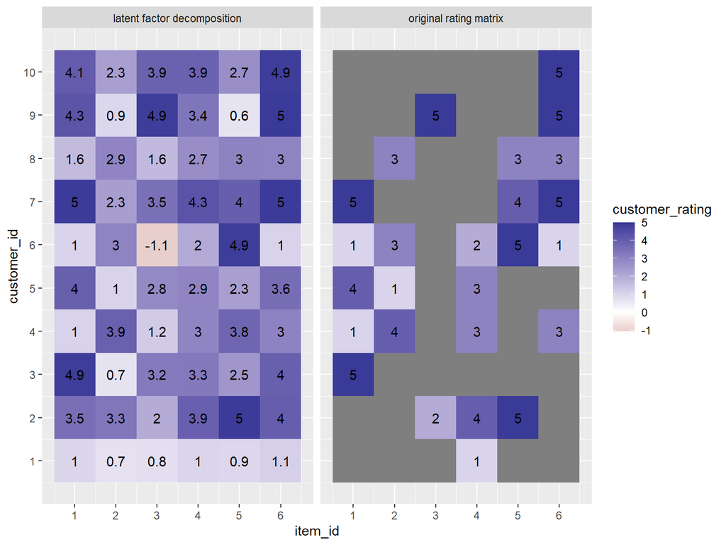

```r
rating_matrix_for_ggplot_heatmap <-
  rating_matrix %>%
    as.matrix() %>%
    as.data.frame() %>%
    rownames_to_column( var="customer_id" ) %>%
    mutate( customer_id = as.numeric( gsub("customer", "", customer_id) ) ) %>%
    pivot_longer(      cols = starts_with("item"),
                   names_to = "item_id",
                  values_to = "customer_rating"
                ) %>%
    mutate( item_id = as.numeric( gsub("item", "", item_id) ) ) %>%
    mutate( customer_rating = if_else(customer_rating==0, as.numeric(NA), customer_rating) ) %>%
    mutate( customer_rating_text = if_else(customer_rating==0, " ", as.character(customer_rating))  )

lat_decomp_mat_for_ggplot_heatmap <-
  latent_decomp_matrix %>%
    as.matrix() %>%
    as.data.frame() %>%
    rownames_to_column( var="customer_id" ) %>%
    mutate( customer_id = as.numeric( gsub("customer", "", customer_id) ) ) %>%
    pivot_longer(      cols = starts_with("item"),
                   names_to = "item_id",
                  values_to = "predicted_customer_rating"
                ) %>%
    mutate( item_id = as.numeric( gsub("item", "", item_id) ) )

bind_rows(
           rating_matrix_for_ggplot_heatmap %>% mutate( source = "original rating matrix" )
           ,
           lat_decomp_mat_for_ggplot_heatmap %>%
             mutate( source = "latent factor decomposition" ) %>%
             rename( customer_rating = predicted_customer_rating) %>%
             mutate( customer_rating_text = as.character( round(customer_rating, digits=1) ) )
         ) %>%
  ggplot( data = .,
          aes(     x = item_id,
                   y = customer_id,
                fill = customer_rating,
               label = customer_rating_text
             )
        ) +
  geom_tile() +
  geom_text() +
  facet_wrap( ~source ) +
  scale_x_continuous( breaks = 1:n_items ) +
  scale_y_continuous( breaks = 1:n_customers ) +
  scale_fill_gradient2()
```

# Estimate latent factor matrices by stochastic gradient descent

```r
lambda1 <- 0.1
lambda2 <- 0.1

calc_gradient_ij_ftn <- function( Umat, Vmat, Ymat, lamb1, lamb2, i, j ){

  list(
        u_grad_row_i =
            2 * (Ymat[i,j] - t(Umat[i,])%*%Vmat[j,]) %*% Vmat[j,] + ( (2*lamb1)/ sum(Ymat[i,]>0) )*Umat[i,],

        v_grad_row_j =
            2 * (Ymat[i,j] - t(Umat[i,])%*%Vmat[j,]) %*% Umat[i,] + ( (2*lamb2)/ sum(Ymat[,j]>0) )*Vmat[j,]
      ) %>%
    return(.)

}

calc_SSE <- function( Umat, Vmat, Ymat, lamb1, lamb2 ){
          sum(
               (
                 Ymat -
                 (  ( Umat %*% t(Vmat) ) * (as.matrix(Ymat>0)*1)  )
               )^2
             ) +
          lamb1 * sum(Umat^2) +
          lamb2 * sum(Vmat^2)
}
```

Set starting values for $U$ matrix and $V$ matrix:

```r
# define dimension
dim_L <- 5
dim_M <- nrow(rating_matrix)
dim_N <- ncol(rating_matrix)

U_matrix <- matrix( data = rnorm( n=dim_M * dim_L),
                    nrow = dim_M,
                    ncol = dim_L
                  )
colnames(U_matrix) <- paste("u", 1:ncol(U_matrix), sep="")

V_matrix <- matrix( data = rnorm( n=dim_N * dim_L),
                    nrow = dim_N,
                    ncol = dim_L
                  )
colnames(V_matrix) <- paste("v", 1:ncol(V_matrix), sep="")

U_matrix
```

```
##                u1         u2         u3          u4         u5
##  [1,]  0.34142008 -0.9041727 -1.3031794  1.15982632 -0.2569052
##  [2,] -0.34292798  3.3281510 -0.9308069 -0.02572129 -0.4292020
##  [3,] -1.39342881 -1.7456589  0.2040854  0.21096395  0.5905360
##  [4,] -0.15715951  0.2134883  0.2972508  1.66011090 -0.6520058
##  [5,] -1.16897807  0.5233318 -0.6347500 -0.53416389 -0.3198558
##  [6,] -0.75053296  1.4581468  1.4985121 -0.42782269  1.3617896
##  [7,] -2.76084336  0.4612746 -1.5784465  1.37855985 -0.7953458
##  [8,] -0.06387764  0.5243600  1.4142414  1.33826502  1.1589157
##  [9,]  1.06721197 -1.9558692  0.2908284 -1.08488031  0.8645589
## [10,]  0.42782715  0.6899987 -1.0177071  2.62589823  1.1684527
```

```r
V_matrix
```

```
##              v1          v2          v3          v4         v5
## [1,]  0.0648527 -0.03799328 -0.45580030  0.20220750 -2.0700295
## [2,] -1.8853768  0.01529262  0.03184695  2.18079112 -0.3738905
## [3,]  1.1705522 -0.29889557 -1.60626774  0.01335225 -0.9954540
## [4,]  0.3686842 -0.25216894 -0.21300247  0.19988617 -0.4049079
## [5,] -0.9470955 -1.64130891  0.23786579 -1.21930910 -1.3836107
## [6,]  0.4773424  0.89092983  1.54138108  0.01064320 -0.4811042
```

```r
learnrate_alpha <- 0.001

for( iteration_i in 0:1000 ){

  # print out SSE every 50 iterations:
  if( iteration_i%%50 == 0 ){
        paste0( "iteration ", iteration_i ) %>% print()

  # print out the objective function value:
  cat("Sum of Squared Errors:  ")
  calc_SSE( Umat = U_matrix,
            Vmat = V_matrix,
            Ymat = rating_matrix,
            lamb1 = lambda1,
            lamb2 = lambda2
          ) %>%
    cat()
  }

  # choose a random non-zero value from the rating matrix:
  rand_i <- sample( which(rowSums(rating_matrix)>0), size=1 )     # choose a random row which has one or more non-zero ratings
  rand_j <- sample( which(rating_matrix[rand_i,]>0), size=1 )

  # calculate gradient for U_i and V_j:
  calc_grads <- calc_gradient_ij_ftn( Umat = U_matrix,
                                      Vmat = V_matrix,
                                      Ymat = rating_matrix,
                                      lamb1 = lambda1,
                                      lamb2 = lambda2,
                                      i = rand_i,
                                      j = rand_j
                                    )

  # update u_i:
  U_matrix[rand_i,] <- U_matrix[rand_i,] + learnrate_alpha * calc_grads$u_grad_row_i

  # update v_i:
  V_matrix[rand_j,] <- V_matrix[rand_j,] + learnrate_alpha * calc_grads$v_grad_row_j

}
```

```
## [1] "iteration 0"
## Sum of Squared Errors:  529.9784[1] "iteration 50"
## Sum of Squared Errors:  485.226[1] "iteration 100"
## Sum of Squared Errors:  432.6712[1] "iteration 150"
## Sum of Squared Errors:  386.9543[1] "iteration 200"
## Sum of Squared Errors:  353.1972[1] "iteration 250"
## Sum of Squared Errors:  325.0263[1] "iteration 300"
## Sum of Squared Errors:  301.5124[1] "iteration 350"
## Sum of Squared Errors:  286.6581[1] "iteration 400"
## Sum of Squared Errors:  267.1335[1] "iteration 450"
## Sum of Squared Errors:  248.4373[1] "iteration 500"
## Sum of Squared Errors:  236.9006[1] "iteration 550"
## Sum of Squared Errors:  226.5514[1] "iteration 600"
## Sum of Squared Errors:  218.4138[1] "iteration 650"
## Sum of Squared Errors:  207.9471[1] "iteration 700"
## Sum of Squared Errors:  199.7251[1] "iteration 750"
## Sum of Squared Errors:  188.4471[1] "iteration 800"
## Sum of Squared Errors:  180.3732[1] "iteration 850"
## Sum of Squared Errors:  173.1026[1] "iteration 900"
## Sum of Squared Errors:  169.1629[1] "iteration 950"
## Sum of Squared Errors:  160.8256[1] "iteration 1000"
## Sum of Squared Errors:  150.713
```

```r
latent_decomp_matrix <- U_matrix %*% t(V_matrix)
rownames(latent_decomp_matrix) <- rownames(rating_matrix)
colnames(latent_decomp_matrix) <- colnames(rating_matrix)

rating_matrix
```

```
## 10 x 6 sparse Matrix of class "dgCMatrix"
##            item1 item2 item3 item4 item5 item6
## customer1      .     .     .     1     .     .
## customer2      .     .     2     4     5     .
## customer3      5     .     .     .     .     .
## customer4      1     4     .     3     .     3
## customer5      4     1     .     3     .     .
## customer6      1     3     .     2     5     1
## customer7      5     .     .     .     4     5
## customer8      .     3     .     .     3     3
## customer9      .     .     5     .     .     5
## customer10     .     .     .     .     .     5
```

```r
latent_decomp_matrix
```

```
##                 item1      item2        item3      item4       item5      item6
## customer1   0.8088318  0.8590295  2.080774413  0.1631399 -1.62651020 -0.8403939
## customer2   1.3609923  1.0469330  0.365529034  3.0734355  2.89597627 -0.4557935
## customer3   4.2987038  4.1130086 -1.323388683 -0.6219602  2.51532146 -0.7829076
## customer4   1.6166055  3.8120638 -0.993147806  1.0174131  0.24933438  1.7210029
## customer5   2.6206910  1.6155567  0.007075884  1.1228918  2.76619333 -1.2078815
## customer6  -1.5513200  2.0282165 -5.011965805 -0.2274019  1.82976327  1.1768919
## customer7   5.5645055  8.1868559 -2.284164345  2.2322624  4.32306462 -0.9423142
## customer8  -1.2793585  3.2707478 -4.362659568 -0.5135927 -0.04393696  2.2012010
## customer9  -1.8648066 -5.2498518  2.593745601 -2.0350591 -2.56068705 -0.1021302
## customer10 -1.7908900  2.8594104 -0.299214775  0.6957607 -3.05804379  0.4826496
```

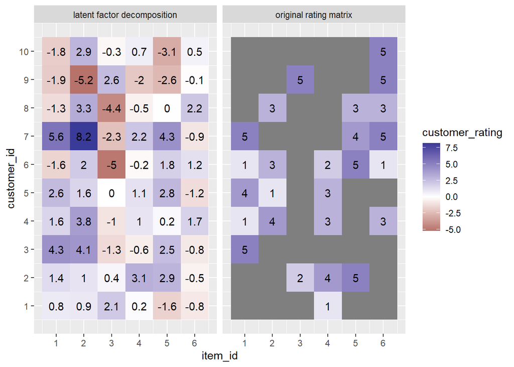

```r
rating_matrix_for_ggplot_heatmap <-
  rating_matrix %>%
    as.matrix() %>%
    as.data.frame() %>%
    rownames_to_column( var="customer_id" ) %>%
    mutate( customer_id = as.numeric( gsub("customer", "", customer_id) ) ) %>%
    pivot_longer(      cols = starts_with("item"),
                   names_to = "item_id",
                  values_to = "customer_rating"
                ) %>%
    mutate( item_id = as.numeric( gsub("item", "", item_id) ) ) %>%
    mutate( customer_rating = if_else(customer_rating==0, as.numeric(NA), customer_rating) ) %>%
    mutate( customer_rating_text = if_else(customer_rating==0, " ", as.character(customer_rating))  )

lat_decomp_mat_for_ggplot_heatmap <-
  latent_decomp_matrix %>%
    as.matrix() %>%
    as.data.frame() %>%
    rownames_to_column( var="customer_id" ) %>%
    mutate( customer_id = as.numeric( gsub("customer", "", customer_id) ) ) %>%
    pivot_longer(      cols = starts_with("item"),
                   names_to = "item_id",
                  values_to = "predicted_customer_rating"
                ) %>%
    mutate( item_id = as.numeric( gsub("item", "", item_id) ) )

bind_rows(
           rating_matrix_for_ggplot_heatmap %>% mutate( source = "original rating matrix" )
           ,
           lat_decomp_mat_for_ggplot_heatmap %>%
             mutate( source = "latent factor decomposition" ) %>%
             rename( customer_rating = predicted_customer_rating) %>%
             mutate( customer_rating_text = as.character( round(customer_rating, digits=1) ) )
         ) %>%
  ggplot( data = .,
          aes(     x = item_id,
                   y = customer_id,
                fill = customer_rating,
               label = customer_rating_text
             )
        ) +
  geom_tile() +
  geom_text() +
  facet_wrap( ~source ) +
  scale_x_continuous( breaks = 1:n_items ) +
  scale_y_continuous( breaks = 1:n_customers ) +
  scale_fill_gradient2()
```

# Resources

1. For recommender theory: that awesome textbook that Dino gave me
2. Really nice high-level video on the theory: Lecture 55 — Latent Factor Recommender System | Stanford University: available at https://www.youtube.com/watch?v=E8aMcwmqsTg
3. For plotting heatmaps in *ggplot2*: heatmapshttps://www.r-graph-gallery.com/79-levelplot-with-ggplot2.html